# Projekt 2 – Predykcja wypożyczeń rowerów miejskich

SAD 2026L

Magdalena Kruk, 458917

2026-06-13

```r
library(tidyverse)
library(lubridate)
library(ggcorrplot)
library(patchwork)
library(ranger)
library(glmnet)
library(rsample)
library(knitr)
library(kableExtra)
```

```r
dow_monday <- function(date) {
  ((as.POSIXlt(date)$wday + 6) %% 7) + 1
}
```

# 1. Podstawowa analiza danych

## 1a. Wczytanie danych i braki wartości

```r
df <- read.csv("bike_train.csv", stringsAsFactors = FALSE)

# Poprawne typy zmiennych
df <- df %>%
  mutate(
    date  = as.Date(date),
    wcond = factor(wcond, levels = 1:4,
                   labels = c("Pogodnie/lekkie zachmurzenie",
                              "Pochmurnie/mgła",
                              "Lekki opad",
                              "Duży opad")),
    # 1d: zmienna weekend
    weekend = as.integer(dow_monday(date) >= 6)
  ) %>%
  select(-any_of(c("X", "Unnamed: 0", "id", "Id", "index")))  # bezpieczne usunięcie kolumny z indeksem, jeśli występuje

# Sprawdzenie braków
braki <- df %>%
  summarise(across(everything(), ~ sum(is.na(.)))) %>%
  pivot_longer(everything(), names_to = "Zmienna", values_to = "Liczba braków")

kable(braki, caption = "Liczba braków wartości w każdej zmiennej") %>%
  kable_styling(bootstrap_options = c("striped", "hover"), full_width = FALSE)
```

Liczba braków wartości w każdej zmiennej

| Zmienna | Liczba braków |
| --- | --- |
| date | 0 |
| wcond | 0 |
| temp | 0 |
| atemp | 0 |
| hum | 0 |
| wind | 0 |
| count | 0 |
| weekend | 0 |

```r
n_missing <- sum(is.na(df))
if (n_missing == 0) {
  cat("**Brak brakujących wartości w zbiorze danych.** Wszystkie zmienne są kompletne – nie ma potrzeby imputacji.")
} else {
  cat(paste0("**Wykryto ", n_missing, " brakujących wartości.** Wiersze z brakami zostaną usunięte (complete case analysis)."))
  df <- df %>% drop_na()
}
```

**Brak brakujących wartości w zbiorze danych.** Wszystkie zmienne są kompletne – nie ma potrzeby imputacji.

> **Uwaga:** W danych występuje obserwacja z `hum = 0`, która może być wartością nietypową lub błędem pomiarowym. Zostaje ona zachowana, ponieważ nie jest formalnie brakiem danych, a pojedyncza obserwacja tego typu nie powinna istotnie zaburzyć wyników modeli.

## 1b. Wykresy: temperatura i liczba wypożyczeń w czasie

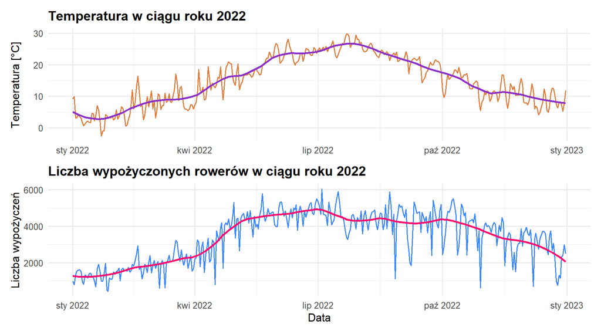

```r
p1 <- ggplot(df, aes(x = date, y = temp)) +
  geom_line(color = "#E07B39", linewidth = 0.7) +
  geom_smooth(se = FALSE, color = "#8B2FC9", linewidth = 0.9, method = "loess", span = 0.2) +
  labs(title = "Temperatura w ciągu roku 2022",
       x = NULL, y = "Temperatura [°C]") +
  theme_minimal(base_size = 12) +
  theme(plot.title = element_text(face = "bold"))

p2 <- ggplot(df, aes(x = date, y = count)) +
  geom_line(color = "#3A86FF", linewidth = 0.7) +
  geom_smooth(se = FALSE, color = "#FF006E", linewidth = 0.9, method = "loess", span = 0.2) +
  labs(title = "Liczba wypożyczonych rowerów w ciągu roku 2022",
       x = "Data", y = "Liczba wypożyczeń") +
  theme_minimal(base_size = 12) +
  theme(plot.title = element_text(face = "bold"))

p1 / p2
```

Oba wykresy wykazują wyraźną **sezonowość**: szczyt wypożyczeń przypada na lato (czerwiec–sierpień), co koreluje z wyższymi temperaturami. Zimą liczba wypożyczeń spada nawet poniżej 1000 dziennie.

## 1c. Macierz korelacji – mapa ciepła

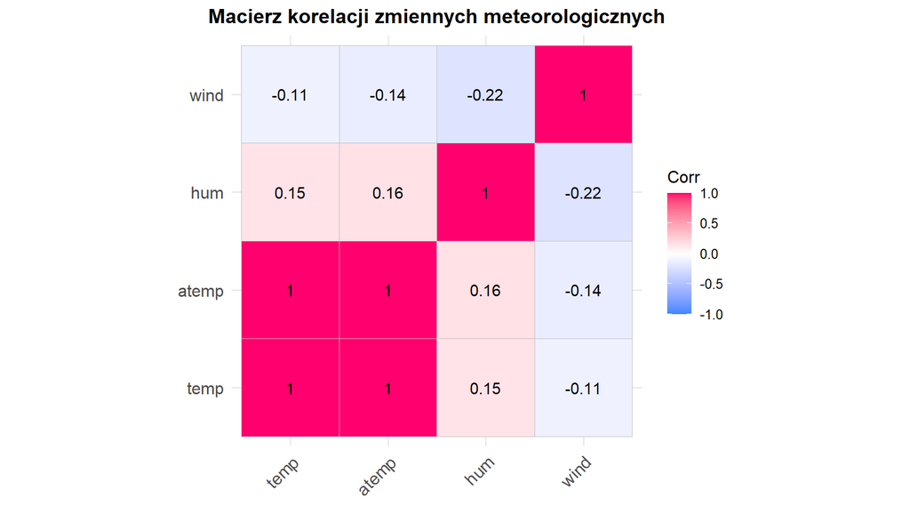

```r
vars_meteo <- df %>% select(temp, atemp, hum, wind)

cor_mat <- cor(vars_meteo, use = "complete.obs")

ggcorrplot(cor_mat,
           method   = "square",
           type     = "full",
           lab      = TRUE,
           lab_size = 4,
           colors   = c("#3A86FF", "white", "#FF006E"),
           title    = "Macierz korelacji zmiennych meteorologicznych",
           ggtheme  = theme_minimal(base_size = 12)) +
  theme(plot.title = element_text(face = "bold", hjust = 0.5))
```

Najsilniejsza korelacja występuje między `temp` a `atemp` (r ≈ 0.99) – obie zmienne niosą praktycznie identyczną informację. `hum` i `wind` są słabo skorelowane z temperaturą.

## 1d. Zmienna `weekend`

Zmienna `weekend` została dodana w sekcji wczytywania danych. Przyjmuje wartość **1** dla sobót i niedziel, **0** dla pozostałych dni.

```r
df %>%
  count(weekend) %>%
  mutate(weekend = ifelse(weekend == 1, "Weekend", "Dzień roboczy"),
         Odsetek = scales::percent(n / sum(n), accuracy = 0.1)) %>%
  rename(Typ = weekend, `Liczba dni` = n) %>%
  kable(caption = "Rozkład zmiennej weekend") %>%
  kable_styling(bootstrap_options = c("striped", "hover"), full_width = FALSE)
```

Rozkład zmiennej weekend

| Typ | Liczba dni | Odsetek |
| --- | --- | --- |
| Dzień roboczy | 260 | 71.2% |
| Weekend | 105 | 28.8% |

# 2. Analiza składowych głównych (PCA)

```r
pca_data <- df %>% select(temp, atemp, hum, wind)

pca_result <- prcomp(pca_data, center = TRUE, scale. = TRUE)

# Wariancja wyjaśniona przez każdą składową
var_explained <- summary(pca_result)$importance

kable(var_explained, digits = 4,
      caption = "Wariancja wyjaśniana przez składowe główne") %>%
  kable_styling(bootstrap_options = c("striped", "hover"), full_width = FALSE)
```

Wariancja wyjaśniana przez składowe główne

|  | PC1 | PC2 | PC3 | PC4 |
| --- | --- | --- | --- | --- |
| Standard deviation | 1.4439 | 1.0622 | 0.8853 | 0.0577 |
| Proportion of Variance | 0.5212 | 0.2821 | 0.1959 | 0.0008 |
| Cumulative Proportion | 0.5212 | 0.8032 | 0.9992 | 1.0000 |

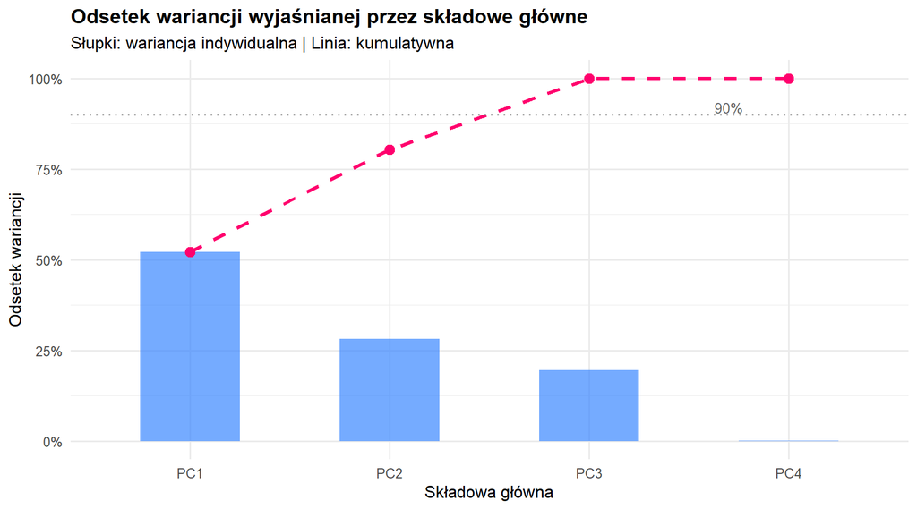

```r
var_df <- data.frame(
  PC          = paste0("PC", 1:4),
  Prop        = var_explained["Proportion of Variance", ],
  Cumulative  = var_explained["Cumulative Proportion", ]
)

ggplot(var_df, aes(x = PC)) +
  geom_col(aes(y = Prop), fill = "#3A86FF", alpha = 0.7, width = 0.5) +
  geom_line(aes(y = Cumulative, group = 1), color = "#FF006E",
            linewidth = 1.2, linetype = "dashed") +
  geom_point(aes(y = Cumulative), color = "#FF006E", size = 3) +
  geom_hline(yintercept = 0.90, linetype = "dotted", color = "gray40") +
  annotate("text", x = 3.7, y = 0.92, label = "90%", color = "gray40", size = 3.5) +
  scale_y_continuous(labels = scales::percent_format()) +
  labs(title    = "Odsetek wariancji wyjaśnianej przez składowe główne",
       subtitle = "Słupki: wariancja indywidualna | Linia: kumulatywna",
       x = "Składowa główna", y = "Odsetek wariancji") +
  theme_minimal(base_size = 12) +
  theme(plot.title = element_text(face = "bold"))
```

```r
n_comp_90 <- which(var_explained["Cumulative Proportion", ] >= 0.90)[1]
cum_90    <- round(var_explained["Cumulative Proportion", n_comp_90] * 100, 1)
cat(paste0("**Minimalna liczba składowych głównych wyjaśniających co najmniej 90% sumarycznej wariancji: ",
           n_comp_90, "** (wyjaśniają łącznie ", cum_90, "% wariancji)."))
```

**Minimalna liczba składowych głównych wyjaśniających co najmniej 90% sumarycznej wariancji: 3** (wyjaśniają łącznie 99.9% wariancji).

# 3. Lasy losowe

## Przygotowanie danych i foldów CV

```r
# Zmienna objaśniana i predyktory
# wcond pozostaje faktorem, ponieważ opisuje jakościowe warunki pogodowe.
# Z daty tworzymy dodatkowe zmienne sezonowe: dzień roku i miesiąc.

df_model <- df %>%
  mutate(
    weekend = as.integer(weekend),
    day_of_year = yday(date),
    month = factor(month(date))
  ) %>%
  select(-date)

set.seed(42)
folds <- vfold_cv(df_model, v = 5, strata = NULL)

# Pomocnicza funkcja: MSE
mse <- function(actual, predicted) mean((actual - predicted)^2)
```

## 3a. Przeszukiwanie siatki hiperparametrów

Wybrane hiperparametry modelu lasów losowych (`ranger`) przedstawiono w tabeli poniżej.

Siatka hiperparametrów modelu lasów losowych.

| Hiperparametr | Opis | Zakres |
| --- | --- | --- |
| num.trees | Liczba drzew w lesie | 100, 200, 300, 500 |
| mtry | Liczba zmiennych losowanych przy podziale w każdym węźle | 2, 3, 4, 5 |
| min.node.size | Minimalna liczba obserwacji w liściu | 2, 3, 5, 8, 10, 15, 20 |

Łącznie przeszukano $4 \times 4 \times 7 = 112$ konfiguracji hiperparametrów, czyli więcej niż wymagane minimum 100 konfiguracji.

```r
# Siatka hiperparametrów: 4 * 4 * 7 = 112 konfiguracji, czyli co najmniej 100
grid_rf <- expand.grid(
  num.trees     = c(100, 200, 300, 500),
  mtry          = c(2, 3, 4, 5),
  min.node.size = c(2, 3, 5, 8, 10, 15, 20)
)

results_rf <- list()

for (i in seq_len(nrow(grid_rf))) {
  nt  <- grid_rf$num.trees[i]
  mt  <- grid_rf$mtry[i]
  mns <- grid_rf$min.node.size[i]

  fold_train_mse <- numeric(5)
  fold_val_mse   <- numeric(5)

  for (f in 1:5) {
    train_f <- training(folds$splits[[f]])
    test_f  <- testing(folds$splits[[f]])

    m <- ranger(
      count ~ .,
      data          = train_f,
      num.trees     = nt,
      mtry          = mt,
      min.node.size = mns,
      seed          = 42
    )

    pred_train <- predict(m, data = train_f)$predictions
    pred_val   <- predict(m, data = test_f)$predictions

    fold_train_mse[f] <- mse(train_f$count, pred_train)
    fold_val_mse[f]   <- mse(test_f$count, pred_val)
  }

  results_rf[[i]] <- data.frame(
    num.trees     = nt,
    mtry          = mt,
    min.node.size = mns,
    train_mse     = mean(fold_train_mse),
    val_mse       = mean(fold_val_mse)
  )
}

rf_results <- bind_rows(results_rf)

best_rf_idx <- which.min(rf_results$val_mse)
best_rf     <- rf_results[best_rf_idx, ]

# Ponowne policzenie wyników w poszczególnych foldach dla najlepszej konfiguracji.
# Jest to potrzebne do tabelarycznego porównania modeli na tych samych foldach.
rf_best_folds <- tibble(
  fold = 1:5,
  train_mse = NA_real_,
  val_mse = NA_real_
)

for (f in 1:5) {
  train_f <- training(folds$splits[[f]])
  test_f  <- testing(folds$splits[[f]])

  m_best_rf <- ranger(
    count ~ .,
    data          = train_f,
    num.trees     = best_rf$num.trees,
    mtry          = best_rf$mtry,
    min.node.size = best_rf$min.node.size,
    seed          = 42
  )

  pred_train <- predict(m_best_rf, data = train_f)$predictions
  pred_val   <- predict(m_best_rf, data = test_f)$predictions

  rf_best_folds$train_mse[f] <- mse(train_f$count, pred_train)
  rf_best_folds$val_mse[f]   <- mse(test_f$count, pred_val)
}
```

## 3b. Wykres: błąd treningowy vs. walidacyjny

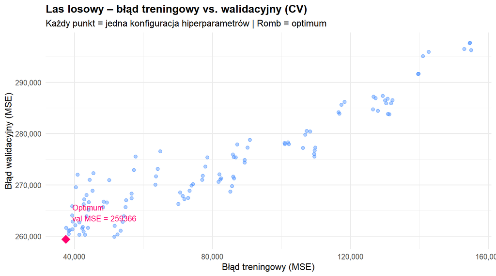

```r
ggplot(rf_results, aes(x = train_mse, y = val_mse)) +
  geom_point(alpha = 0.4, color = "#3A86FF", size = 2) +
  geom_point(data = best_rf,
             aes(x = train_mse, y = val_mse),
             color = "#FF006E", size = 5, shape = 18) +
  annotate("text",
           x = best_rf$train_mse * 1.05,
           y = best_rf$val_mse   * 1.02,
           label = paste0("Optimum\nval MSE = ", round(best_rf$val_mse, 0)),
           color = "#FF006E", size = 3.5, hjust = 0) +
  scale_x_continuous(labels = scales::comma) +
  scale_y_continuous(labels = scales::comma) +
  labs(title    = "Las losowy – błąd treningowy vs. walidacyjny (CV)",
       subtitle = "Każdy punkt = jedna konfiguracja hiperparametrów | Romb = optimum",
       x = "Błąd treningowy (MSE)",
       y = "Błąd walidacyjny (MSE)") +
  theme_minimal(base_size = 12) +
  theme(plot.title = element_text(face = "bold"))
```

```r
cat(paste0(
  "**Optymalna konfiguracja lasów losowych:**\n\n",
  "- `num.trees` = ", best_rf$num.trees, "\n",
  "- `mtry` = ", best_rf$mtry, "\n",
  "- `min.node.size` = ", best_rf$min.node.size, "\n\n",
  "**Błąd walidacyjny (MSE) = ", round(best_rf$val_mse, 2), "**",
  " (RMSE ≈ ", round(sqrt(best_rf$val_mse), 1), " wypożyczeń)"
))
```

**Optymalna konfiguracja lasów losowych:**

- `num.trees` = 500
- `mtry` = 5
- `min.node.size` = 2

**Błąd walidacyjny (MSE) = 259365.92** (RMSE ≈ 509.3 wypożyczeń)

# 4. Regresja grzbietowa (Ridge)

## 4a. Walidacja krzyżowa dla siatki λ

```r
# Przygotowanie macierzy modelu
X_all <- model.matrix(count ~ . - 1, data = df_model)
y_all <- df_model$count

# Siatka lambda – 10 wartości (zakres od 10000 do 0.01)
lambda_grid <- 10^seq(4, -2, length.out = 10)

# Wyniki per fold i per lambda
ridge_results <- expand.grid(
  lambda   = lambda_grid,
  fold     = 1:5,
  val_mse  = NA_real_
)

for (f in 1:5) {
  idx_train <- folds$splits[[f]]$in_id
  idx_test  <- setdiff(seq_len(nrow(df_model)), idx_train)

  X_train <- X_all[idx_train, ]
  y_train <- y_all[idx_train]
  X_test  <- X_all[idx_test,  ]
  y_test  <- y_all[idx_test]

  for (l_idx in seq_along(lambda_grid)) {
    lam <- lambda_grid[l_idx]

    m_ridge <- glmnet(X_train, y_train, alpha = 0, lambda = lam)
    pred    <- predict(m_ridge, newx = X_test, s = lam)

    row_idx <- which(ridge_results$lambda == lam & ridge_results$fold == f)
    ridge_results$val_mse[row_idx] <- mse(y_test, as.vector(pred))
  }
}

# Błąd CV (uśredniony po foldach) dla każdej lambdy
ridge_cv <- ridge_results %>%
  group_by(lambda) %>%
  summarise(cv_mse = mean(val_mse), .groups = "drop")

best_ridge     <- ridge_cv %>% slice_min(cv_mse, n = 1, with_ties = FALSE)
best_ridge_mse <- best_ridge$cv_mse
best_lambda    <- best_ridge$lambda

ridge_best_folds <- ridge_results %>%
  filter(lambda == best_lambda) %>%
  arrange(fold) %>%
  select(fold, val_mse)
```

## 4b. Wykres: MSE w foldach i błąd CV

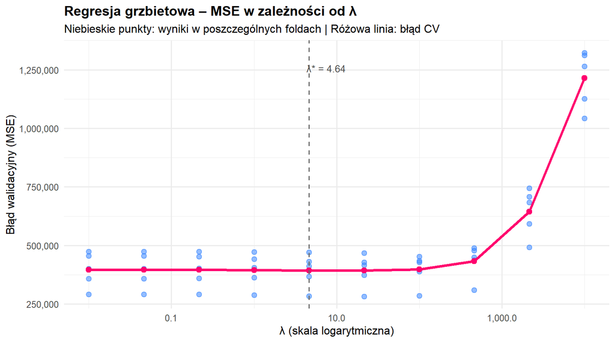

```r
ggplot() +
  # punkty dla każdego foldu
  geom_point(data = ridge_results,
             aes(x = lambda, y = val_mse, group = factor(fold)),
             color = "#3A86FF", alpha = 0.55, size = 2.2) +
  # linia błędu CV
  geom_line(data = ridge_cv,
            aes(x = lambda, y = cv_mse),
            color = "#FF006E", linewidth = 1.3) +
  geom_point(data = ridge_cv,
             aes(x = lambda, y = cv_mse),
             color = "#FF006E", size = 2.5) +
  # oznaczenie optimum
  geom_vline(xintercept = best_lambda, linetype = "dashed", color = "gray40") +
  annotate("text",
           x     = best_lambda * 1.6,
           y     = max(ridge_results$val_mse) * 0.95,
           label = paste0("λ* = ", round(best_lambda, 2)),
           color = "gray30", size = 3.5) +
  scale_x_log10(labels = scales::comma) +
  scale_y_continuous(labels = scales::comma) +
  labs(title    = "Regresja grzbietowa – MSE w zależności od λ",
       subtitle = "Niebieskie punkty: wyniki w poszczególnych foldach | Różowa linia: błąd CV",
       x = "λ (skala logarytmiczna)",
       y = "Błąd walidacyjny (MSE)") +
  theme_minimal(base_size = 12) +
  theme(plot.title = element_text(face = "bold"))
```

## 4c. Optymalne λ i porównanie z lasami losowymi

```r
cat(paste0(
  "**Optymalne λ = ", round(best_lambda, 4), "**",
  " przy którym błąd walidacyjny (MSE) wynosi **",
  round(best_ridge_mse, 2), "** (RMSE ≈ ",
  round(sqrt(best_ridge_mse), 1), " wypożyczeń).\n\n",
  "Dla porównania, najlepszy model lasów losowych osiągnął błąd walidacyjny **",
  round(best_rf$val_mse, 2), "** (RMSE ≈ ",
  round(sqrt(best_rf$val_mse), 1), " wypożyczeń)."
))
```

**Optymalne λ = 4.6416** przy którym błąd walidacyjny (MSE) wynosi **393106.99** (RMSE ≈ 627 wypożyczeń).

Dla porównania, najlepszy model lasów losowych osiągnął błąd walidacyjny **259365.92** (RMSE ≈ 509.3 wypożyczeń).

# 5. Podsumowanie tabelaryczne – porównanie modeli

```r
# Model bazowy: predykcja = średnia z foldów treningowych
baseline_mse_folds <- numeric(5)

for (f in 1:5) {
  train_f <- training(folds$splits[[f]])
  test_f  <- testing(folds$splits[[f]])

  mean_train    <- mean(train_f$count)
  pred_baseline <- rep(mean_train, nrow(test_f))

  baseline_mse_folds[f] <- mse(test_f$count, pred_baseline)
}

baseline_cv_mse <- mean(baseline_mse_folds)

# Tabela fold po foldzie – wszystkie modele są liczone na tych samych podziałach CV
comparison_folds <- tibble(
  Fold = 1:5,
  `Model bazowy MSE` = baseline_mse_folds,
  `Ridge MSE` = ridge_best_folds$val_mse,
  `Random Forest MSE` = rf_best_folds$val_mse
)

comparison_folds_with_mean <- comparison_folds %>%
  bind_rows(tibble(
    Fold = NA_integer_,
    `Model bazowy MSE` = mean(baseline_mse_folds),
    `Ridge MSE` = mean(ridge_best_folds$val_mse),
    `Random Forest MSE` = mean(rf_best_folds$val_mse)
  )) %>%
  mutate(Fold = ifelse(is.na(Fold), "Średnia", as.character(Fold)))
```

```r
kable(
  comparison_folds_with_mean,
  digits = 2,
  caption = "Porównanie modeli w poszczególnych foldach walidacji krzyżowej"
) %>%
  kable_styling(bootstrap_options = c("striped", "hover", "bordered"),
                full_width = FALSE) %>%
  row_spec(nrow(comparison_folds_with_mean), bold = TRUE, background = "#f2f2f2")
```

Porównanie modeli w poszczególnych foldach walidacji krzyżowej

| Fold | Model bazowy MSE | Ridge MSE | Random Forest MSE |
| --- | --- | --- | --- |
| 1 | 2024546 | 431535.2 | 263577.8 |
| 2 | 1730364 | 284328.0 | 171937.4 |
| 3 | 1977498 | 367739.2 | 280941.6 |
| 4 | 1987010 | 410686.4 | 330638.3 |
| 5 | 1784895 | 471246.3 | 249734.5 |
| Średnia | 1900863 | 393107.0 | 259365.9 |

```r
summary_df <- tibble(
  Model = c(
    "Model bazowy (stała = średnia treningowa)",
    "Regresja grzbietowa (Ridge)",
    "Lasy losowe (Random Forest)"
  ),
  `Błąd CV (MSE)` = c(
    round(baseline_cv_mse, 2),
    round(best_ridge_mse,  2),
    round(best_rf$val_mse, 2)
  ),
  `RMSE` = c(
    round(sqrt(baseline_cv_mse), 1),
    round(sqrt(best_ridge_mse),  1),
    round(sqrt(best_rf$val_mse), 1)
  ),
  `Względny błąd vs. baseline [%]` = c(
    "–",
    paste0(round((best_ridge_mse  / baseline_cv_mse - 1) * 100, 1), "%"),
    paste0(round((best_rf$val_mse / baseline_cv_mse - 1) * 100, 1), "%")
  )
)

kable(summary_df,
      caption = "Porównanie modeli – średni wynik z 5-krotnej walidacji krzyżowej") %>%
  kable_styling(bootstrap_options = c("striped", "hover", "bordered"),
                full_width = FALSE) %>%
  row_spec(which.min(c(baseline_cv_mse, best_ridge_mse, best_rf$val_mse)),
           bold = TRUE, background = "#d4edda")
```

Porównanie modeli – średni wynik z 5-krotnej walidacji krzyżowej

| Model | Błąd CV (MSE) | RMSE | Względny błąd vs. baseline [%] |
| --- | --- | --- | --- |
| Model bazowy (stała = średnia treningowa) | 1900862.6 | 1378.7 | – |
| Regresja grzbietowa (Ridge) | 393107.0 | 627.0 | -79.3% |
| Lasy losowe (Random Forest) | 259365.9 | 509.3 | -86.4% |

**Wnioski:**

- Model bazowy (predykcja stałą = średnią) stanowi dolną granicę jakości – RMSE na poziomie ok. 1379 wypożyczeń.
- Regresja grzbietowa istotnie poprawia wynik względem modelu bazowego, lecz jest modelem liniowym i nie potrafi uchwycić nieliniowych zależności.
- Lasy losowe osiągają najniższy błąd walidacyjny, co wskazuje na ich przewagę w tym zadaniu – lepiej modelują nieliniowe relacje (np. efekt wysokich temperatur latem, wpływ opadów).

# 6. Predykcja na zbiorze testowym (Kaggle)

Do finalnej predykcji na zbiorze testowym wykorzystano osobny skrypt `KrukMagdalena_458917_kaggle.R`.Rozwiązanie jest modelem zespołowym, w którym wykorzystano:

- dwa modele gradient boosting (`gbm`),
- dwa modele lasów losowych (`ranger`),
- dwa modele `xgboost`,
- regresję grzbietową (`glmnet`, Ridge),
- model wygładzający GAM (`mgcv`).

Zmienną objaśnianą w modelach finalnych jest `log_count = log(1 + count)`, co stabilizuje wariancję i ogranicza wpływ bardzo dużych wartości liczby wypożyczeń. Po predykcji wynik jest przekształcany z powrotem do oryginalnej skali przez `exp(pred) - 1`.

W finalnym skrypcie wykorzystano wyłącznie trzy pliki wejściowe:

- `bike_train.csv` – dane treningowe z kolumną `count`,
- `bike_test.csv` – dane testowe bez kolumny `count`,
- `sample_submission.csv` – wzór formatu pliku wynikowego.

```r
if (file.exists("KrukMagdalena_458917_kaggle.R")) {
  source("KrukMagdalena_458917_kaggle.R")

  if (file.exists("submission.csv")) {
    submission_check <- read.csv("submission.csv", stringsAsFactors = FALSE)
    sample_check <- read.csv("sample_submission.csv", stringsAsFactors = FALSE)

    stopifnot(all(c("date", "pred") %in% names(submission_check)))
    stopifnot(nrow(submission_check) == nrow(sample_check))
    stopifnot(!any(is.na(submission_check$pred)))
    stopifnot(all(is.finite(submission_check$pred)))
    stopifnot(all(submission_check$pred >= 0))

    write.csv(
      submission_check[, c("date", "pred")],
      "KrukMagdalena_458917_submission.csv",
      row.names = FALSE
    )

    head(submission_check) %>%
      kable(caption = "Pierwsze wiersze finalnego pliku submission") %>%
      kable_styling(bootstrap_options = c("striped", "hover"), full_width = FALSE)
  }
} else {
  cat("Plik KrukMagdalena_458917_kaggle.R nie został znaleziony w folderze roboczym. Finalny model znajduje się w osobnym skrypcie i należy uruchomić go w tym samym folderze co bike_train.csv, bike_test.csv oraz sample_submission.csv.")
}
```

```
## Gotowe, zapisano submission.csv
```

Pierwsze wiersze finalnego pliku submission

| date | pred |
| --- | --- |
| 2023-01-01 | 1072.2792 |
| 2023-01-02 | 912.9903 |
| 2023-01-03 | 923.3402 |
| 2023-01-04 | 1346.8241 |
| 2023-01-05 | 1817.7429 |
| 2023-01-06 | 2035.6743 |

Ostateczny plik wynikowy ma dwie kolumny:

- `date` – data ze zbioru testowego,
- `pred` – przewidywana liczba wypożyczeń rowerów.

Taki format jest zgodny z plikiem `sample_submission.csv`.